# 03_function_imput_raw_rtqpcr

Maria Dermit

06/10/2020

### Loading libraries

```r
library(tidyverse)
library(readxl) #this package let us read an excel file into R
library(here) #this package let us organise files in path easily
```

### Reading the excel file

```r
rtpcr_data_raw <- read_excel(here("slides","03-raw_rtqPCR_functions","data", "C1_HCT116plus_180820rep_data.xls"),
sheet = 1, na = "Undetermined",
skip = 7, n_max = 72)
```

Kalis RT-qPCR data consist of two experiements:  
1:  
Cells max  
Con si (control)  
C1 si  
2:  
Cells max LNA A (control) LNA 1  
LNA 2

She did these two experiments with two sets of primers: 2-3 primers and C1 protein. Her housekeeping control are two: GAPDH and RPS18 and she usually does the mean of the two for the delta Ct.

So in the `rtpcr_data_raw` data that we read the columns we can select the columns we are interested in:

```r
rtpcr_data_mean_CT <- rtpcr_data_raw %>%
  select( "Sample"="Sample Name", "Target"="Target Name", "CT" = "Cт") %>%
  arrange(Sample, Target) %>%
 filter(!(Sample=="LNA 1" & Target=="GAPDH" & CT >20)) %>%
  group_by(Sample,Target) %>%
  summarise(meanCT=mean(CT)) %>%
  spread(Target,meanCT) %>%
  gather(Target, meanCT, -Sample, -GAPDH,-RPS18) %>%
   group_by(Sample)%>%
   mutate(housekeeping=(GAPDH+RPS18)/2) %>%
  select(-GAPDH,-RPS18)
```

This is a relative complex number of steps so we could automate them writing a function like so:

```r
get_CT_housekeeping <- function(x){
  x %>%
    select( "Sample"="Sample Name", "Target"="Target Name", "CT" = "Cт") %>%
  arrange(Sample, Target) %>%
 filter(!(Sample=="LNA 1" & Target=="GAPDH" & CT >20)) %>%
  group_by(Sample,Target) %>%
  summarise(meanCT=mean(CT)) %>%
  spread(Target,meanCT) %>%
  gather(Target, meanCT, -Sample, -GAPDH,-RPS18) %>%
   group_by(Sample)%>%
   mutate(housekeeping=(GAPDH+RPS18)/2) %>%
  select(-GAPDH,-RPS18)
}
```

And then we input our `rtpcr_data_raw` into the function like so:

```r
rtpcr_data_mean_CT <- get_CT_housekeeping(rtpcr_data_raw)
```

There were some values that came as “Undetermined” in the raw data, we can transform those to CT value 40 (aka high CT values).

```r
rtpcr_data_mean_CT$meanCT[is.na(rtpcr_data_mean_CT$meanCT)]=40
```

### Calculate Δ Ct

```r
rtpcr_data_deltaCT <- rtpcr_data_mean_CT %>%
  mutate(deltaCT = meanCT - housekeeping)
```

Control samples are Con si. We need to calculate the mean ΔCt of the two different targets (2_3 & C1) that Kali tested.

```r
#Calculate ΔΔCt
Control_average_2_3<- rtpcr_data_deltaCT %>%
  as_tibble() %>%
  mutate_if(is.character,as.factor) %>%
  filter(str_detect(Sample, c("Con si","LNA A")) &     str_detect(Target, "2-3")) %>%
   pull(deltaCT)

Control_average_C1<- rtpcr_data_deltaCT %>%
  as_tibble() %>%
  mutate_if(is.character,as.factor) %>%
  filter(str_detect(Sample, c("Con si","LNA A")) & str_detect(Target, "protein")) %>%
   pull(deltaCT)
```

We can now calculate ΔΔCt:

```r
deltadeltaCT <- rtpcr_data_deltaCT %>%
  mutate(ddCT = case_when(
    Target == "C1 2-3" & str_detect(Sample,"LNA") ~
      deltaCT -     Control_average_2_3[2],
     Target == "C1 2-3" & str_detect(Sample,"LNA", negate=TRUE) ~        deltaCT - Control_average_2_3[1],
    Target == "C1 protein" & str_detect(Sample,"LNA") ~
      deltaCT - Control_average_C1[2],
  Target == "C1 protein" & str_detect(Sample,"LNA", negate=TRUE) ~
      deltaCT - Control_average_C1[1]
  ))
```

And we can calculate expression values:

```r
expression_values<- deltadeltaCT %>%
  mutate(expression = 2^(-ddCT)) %>%
  mutate_if(is.character,as.factor)
```

```
## `mutate_if()` ignored the following grouping variables:
## Column `Sample`
```

```r
#Creating this column to short column order in plot
expression_values$rep=c(1:12)
```

We can now plot the expression values

```r
expression_plot<-expression_values %>%
  arrange(-rep) %>%
ggplot(aes(x =  fct_inorder(Sample), y = expression, color = Target)) +
  geom_point(position = position_dodge(0.3), alpha = 0.5) +
  xlab("Sample")
```

We could save this plot. Initially we create a folder inside our session 3:

```r
suppressWarnings(dir.create(paste0(paste0(here(),"/slides","/03-raw_rtqPCR_functions"),"/plots")))
```

And then we can save the plot with:

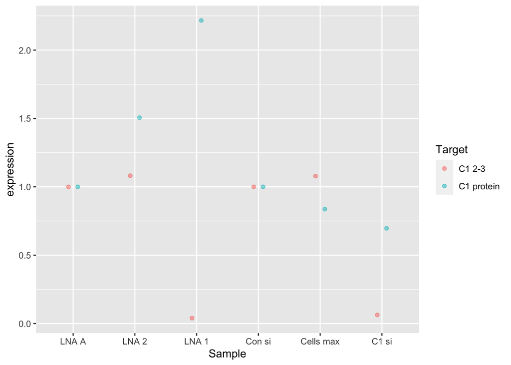

```r
expression_plot+  ggsave(here("slides", "03-raw_rtqPCR_functions","plots","expression_plot.png"))
```

### Concluding remarks

There is anoter RT-qPCR in the `data` folder of this session called `HCT116plus_RNAi_LNA_180920_data.xls`. Could you represent the expresion values of this experiment? Could you write additional functinos to further automate RT-qPCR representation?